# p8105_hw3_yh3429

2022-10-10

#### **Load the data from the `p8015.datasets`**

```r
library(tidyverse)
library(ggplot2)
library(p8105.datasets)
library(ggridges)
library(patchwork)
```

## Problem 1

#### Read in the data

```r
data("instacart")

instacart =
  instacart %>%
  as_tibble(instacart)
```

#### Answer questions about the data

This dataset contains 1384617 rows and 15 columns, with each row resprenting a single product from an instacart order. Variables include identifiers for user, order, and product; the order in which each product was added to the cart. There are several order-level variables, describing the day and time of the order, and number of days since prior order. Then there are several item-specific variables, describing the product name (e.g. Yogurt, Avocado), department (e.g. dairy and eggs, produce), and aisle (e.g. yogurt, fresh fruits), and whether the item has been ordered by this user in the past. In total, there are 39123 products found in 131209 orders from 131209 distinct users.

Below is a table summarizing the number of items ordered from aisle. In total, there are 134 aisles, with fresh vegetables and fresh fruits holding the most items ordered by far.

```r
instacart %>%
  count(aisle) %>%
  arrange(desc(n))
```

```
## # A tibble: 134 × 2
##    aisle                              n
##    <chr>                          <int>
##  1 fresh vegetables              150609
##  2 fresh fruits                  150473
##  3 packaged vegetables fruits     78493
##  4 yogurt                         55240
##  5 packaged cheese                41699
##  6 water seltzer sparkling water  36617
##  7 milk                           32644
##  8 chips pretzels                 31269
##  9 soy lactosefree                26240
## 10 bread                          23635
## # … with 124 more rows
```

Next is a plot that shows the number of items ordered in each aisle. Here, aisles are ordered by ascending number of items.

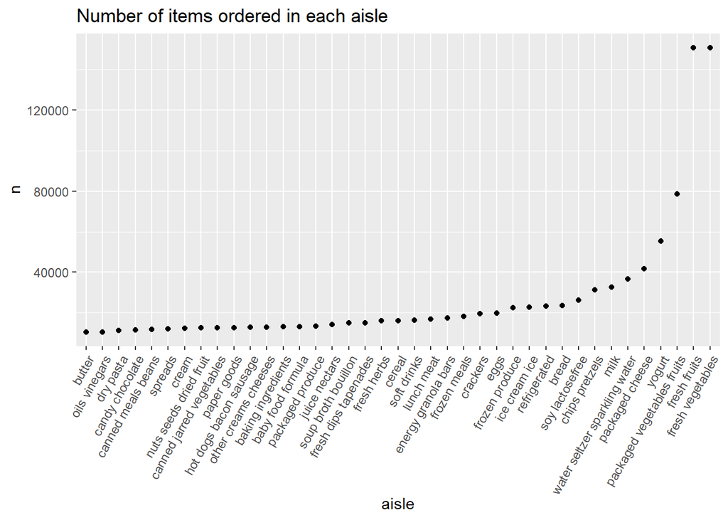

```r
instacart %>%
  count(aisle) %>%
  filter(n > 10000) %>%
  mutate(aisle = fct_reorder(aisle, n)) %>%
  ggplot(aes(x = aisle, y = n)) +
  geom_point() +
  labs(title = "Number of items ordered in each aisle") +
  theme(axis.text.x = element_text(angle = 60, hjust = 1))
```

Our next table shows the three most popular items in aisles `baking ingredients`, `dog food care`, and `packaged vegetables fruits`, and includes the number of times each item is ordered in your table.

```r
instacart %>%
  filter(aisle %in% c("baking ingredients", "dog food care", "packaged vegetables fruits")) %>%
  group_by(aisle) %>%
  count(product_name) %>%
  mutate(rank = min_rank(desc(n))) %>%
  filter(rank < 4) %>%
  arrange(desc(n)) %>%
  knitr::kable()
```

| aisle | product_name | n | rank |
| --- | --- | --- | --- |
| packaged vegetables fruits | Organic Baby Spinach | 9784 | 1 |
| packaged vegetables fruits | Organic Raspberries | 5546 | 2 |
| packaged vegetables fruits | Organic Blueberries | 4966 | 3 |
| baking ingredients | Light Brown Sugar | 499 | 1 |
| baking ingredients | Pure Baking Soda | 387 | 2 |
| baking ingredients | Cane Sugar | 336 | 3 |
| dog food care | Snack Sticks Chicken & Rice Recipe Dog Treats | 30 | 1 |
| dog food care | Organix Chicken & Brown Rice Recipe | 28 | 2 |
| dog food care | Small Dog Biscuits | 26 | 3 |

Finally is a table showing the mean hour of the day at which Pink Lady Apples and Coffee Ice Cream are ordered on each day of the week. This table has been formatted in an untidy manner for human readers. Pink Lady Apples are generally purchased slightly earlier in the day than Coffee Ice Cream, with the exception of day 5.

```r
instacart %>%
  filter(product_name %in% c("Pink Lady Apples", "Coffee Ice Cream")) %>%
  group_by(product_name, order_dow) %>%
  summarize(mean_hour = mean(order_hour_of_day)) %>%
  spread(key = order_dow, value = mean_hour) %>%
  knitr::kable(digits = 2)
```

| product_name | 0 | 1 | 2 | 3 | 4 | 5 | 6 |
| --- | --- | --- | --- | --- | --- | --- | --- |
| Coffee Ice Cream | 13.77 | 14.32 | 15.38 | 15.32 | 15.22 | 12.26 | 13.83 |
| Pink Lady Apples | 13.44 | 11.36 | 11.70 | 14.25 | 11.55 | 12.78 | 11.94 |

## Problem 2

#### Load and tidy the data. Describe the resulting dataset.

```r
accel = read_csv("./data/accel_data.csv") %>%
  janitor::clean_names() %>%
  pivot_longer( activity_1: activity_1440,
                names_to = "activity_time",
                names_prefix = "activity_",
                values_to = "activity_counts" ) %>%
  mutate((day_of_week= case_when(
    startsWith(day, "Mon") ~ "Weekday",
    startsWith(day, "Tu") ~"Weekday",
    startsWith(day, "We")~"Weekday",
    startsWith(day, "Thu")~"Weekday",
    startsWith(day, "Fri")~"Weekday",
    startsWith(day, "S")~"Weekend")
  ) ) %>%
  mutate(day = as.factor(day), activity_time = as.numeric(activity_time)) %>%
  mutate(day = forcats::fct_relevel(day,c("Monday", "Tuesday", "Wednesday","Thursday", "Friday", "Saturday", "Sunday") ) )
accel
```

```
## # A tibble: 50,400 × 6
##     week day_id day    activity_time activity_counts `(...)`
##    <dbl>  <dbl> <fct>          <dbl>           <dbl> <chr>
##  1     1      1 Friday             1            88.4 Weekday
##  2     1      1 Friday             2            82.2 Weekday
##  3     1      1 Friday             3            64.4 Weekday
##  4     1      1 Friday             4            70.0 Weekday
##  5     1      1 Friday             5            75.0 Weekday
##  6     1      1 Friday             6            66.3 Weekday
##  7     1      1 Friday             7            53.8 Weekday
##  8     1      1 Friday             8            47.8 Weekday
##  9     1      1 Friday             9            55.5 Weekday
## 10     1      1 Friday            10            43.0 Weekday
## # … with 50,390 more rows
```

#### Create a total acitivty variable and a table.Are any trends apparent?

```r
total_activity=
  accel %>% group_by(week, day) %>% summarise(total_activity= sum(activity_counts)) %>%  knitr::kable()
total_activity
```

| week | day | total_activity |
| --- | --- | --- |
| 1 | Monday | 78828.07 |
| 1 | Tuesday | 307094.24 |
| 1 | Wednesday | 340115.01 |
| 1 | Thursday | 355923.64 |
| 1 | Friday | 480542.62 |
| 1 | Saturday | 376254.00 |
| 1 | Sunday | 631105.00 |
| 2 | Monday | 295431.00 |
| 2 | Tuesday | 423245.00 |
| 2 | Wednesday | 440962.00 |
| 2 | Thursday | 474048.00 |
| 2 | Friday | 568839.00 |
| 2 | Saturday | 607175.00 |
| 2 | Sunday | 422018.00 |
| 3 | Monday | 685910.00 |
| 3 | Tuesday | 381507.00 |
| 3 | Wednesday | 468869.00 |
| 3 | Thursday | 371230.00 |
| 3 | Friday | 467420.00 |
| 3 | Saturday | 382928.00 |
| 3 | Sunday | 467052.00 |
| 4 | Monday | 409450.00 |
| 4 | Tuesday | 319568.00 |
| 4 | Wednesday | 434460.00 |
| 4 | Thursday | 340291.00 |
| 4 | Friday | 154049.00 |
| 4 | Saturday | 1440.00 |
| 4 | Sunday | 260617.00 |
| 5 | Monday | 389080.00 |
| 5 | Tuesday | 367824.00 |
| 5 | Wednesday | 445366.00 |
| 5 | Thursday | 549658.00 |
| 5 | Friday | 620860.00 |
| 5 | Saturday | 1440.00 |
| 5 | Sunday | 138421.00 |

*Based on looking at the table, there aren’t any apparent trends presenting.*

#### Make a single-panel plot. Describe in words any patterns.

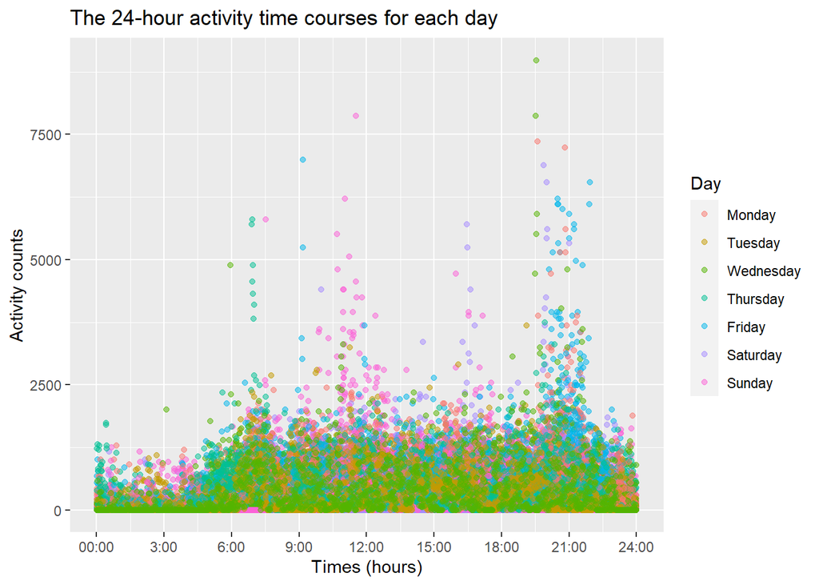

```r
accel %>%
ggplot(aes(x = activity_time, y = activity_counts, group= day)) +
 geom_point(aes(color = day), alpha=0.5)+
    labs(
        x = "Times (hours)",
        y = "Activity counts",
        title = "The 24-hour activity time courses for each day",  color = "Day" )+
  scale_x_continuous(
    breaks = c(0,180,360,540,720,900,1080,1260,1440),
    labels = c("00:00","3:00","6:00","9:00",
               "12:00","15:00","18:00","21:00","24:00")
  )
```

*Based on this graph, this 63 year-old male patient with BMI 25 had a relatively higher activity counts on Friday between 19:00 hour and 22:00 hour. In addition, he also had a relatively higher activity counts on Sunday between 11:00 hour and 12:00 hour.*

## Problem 3

#### Do some data cleaning.

```r
data("ny_noaa")
```

```r
noaa_missing = ny_noaa %>%
  summarize(
    prcp_missing = mean(is.na(prcp)),
    snow_missing = mean(is.na(snow)),
    snwd_missing = mean(is.na(snwd)),
    tmax_missing = mean(is.na(tmax)),
    tmin_missing = mean(is.na(tmin)))
```

```r
ny_noaa_tidy =
  ny_noaa %>%
  janitor::clean_names() %>%
  separate(date, into = c("year", "month", "day")) %>%
  mutate(month = month.name[as.numeric(month)]) %>%
  mutate(year = as.numeric(year),
         tmax = as.numeric(tmax)/10,
         tmin = as.numeric(tmin)/10,
         prcp = as.numeric(prcp)/10)


most_commonly_snowfall=
  count(ny_noaa_tidy, snow) %>%
  arrange(desc(n)) %>% head(n=1)
```

This dataset had **2595176** observations and **9** variables, and the key variables included `id`, `year`, `month`,`day`, `pcrp`, `snow`, `tmax`, and `tmin`.  
The variables `tmax`and `tmin` had relatively more missing data in this dataset, and there was up to 43.7% missing data in these two variables. For snowfall, the most commonly observed values are **0mm**.

#### Make a two-panel plot showing the average **max** temperature in January and in July in each station across years.

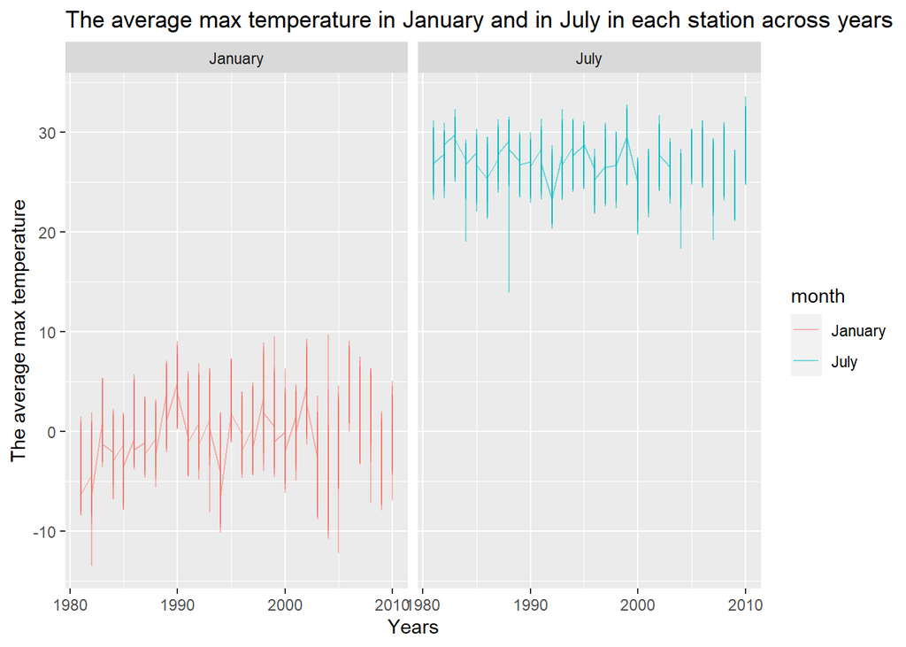

```r
ny_noaa_tidy %>%
    filter(month %in% c("January","July")) %>%
    group_by(id, year, month) %>%
    mutate(average_tmax = mean(tmax, na.rm=TRUE)) %>%
    ggplot(aes(x = year, y= average_tmax, color=month)) +
    geom_line (alpha=0.5) +
    facet_grid(~month) +
    labs(
      x= "Years",
      y= "The average max temperature",
      title= "The average max temperature in January and in July in each station across years"
    )
```

Based on the plot, in January, the average max temperature range was from -10°C to 10°C across years. In July, the average max temperature range was from 22°C to 30°C across years. There were outliers present. For example, in January, there was a distinct outlier about -14 °C. In July, there was an obvious outlier about 14°C.

#### (i)a plot for `tmax` vs `tmin`

```r
tmax_tmin_p =
  ny_noaa_tidy %>%
  ggplot(aes(x = tmin, y = tmax)) +
  geom_hex(alpha = .5) +
  theme(legend.position = "none")+
   labs(
      x= "The minimum temperature (°C)",
      y= "The maximum temperature (°C)",
      title= "The plot for tmax vs tmin"
    )+ theme(legend.position = "right")
```

#### (ii) the distribution plot

```r
snowfall_dens_p =
  ny_noaa_tidy %>%
  mutate(year = as.factor(year)) %>%
  filter(snow > 0, snow < 100) %>%
  ggplot(aes(x = snow, y = year, fill = year))+
  geom_density_ridges(alpha = 0.4)+
   labs(
      x= "The snowfall values (mm)",
      y= "Years",
      title= "The distribution of snowfall values by year"
    )+theme(legend.position = "right")
```

#### Juxtapose two plots

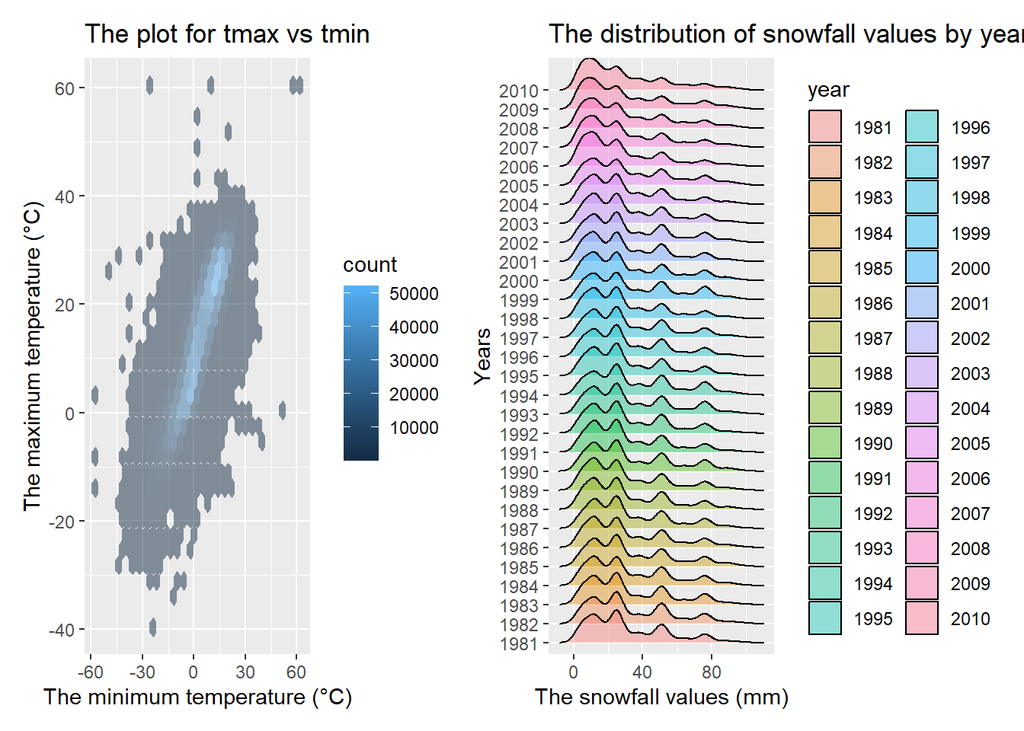

```r
tmax_tmin_p + snowfall_dens_p
```